# FigureYa133m6Apeak_update

小丫画图出品

2020-6-27

欢迎关注“小丫画图”公众号，同名知识星球等你加入

小丫微信: epigenomics E-mail: figureya@126.com

作者：赵龙，中科院遗传所在读博士

擅长：ChIP-seq，MNase-seq，ATAC-seq，HiC，ChIA-PET，GWAS分析，R语言。

兴趣：单细胞RNA-seq，ATAC-seq，机器学习相关。

小丫编辑校验

赵龙更新

# 需求描述

何川组发在nature上的m6a相关的工作，求call差异peak的数据分析部分。

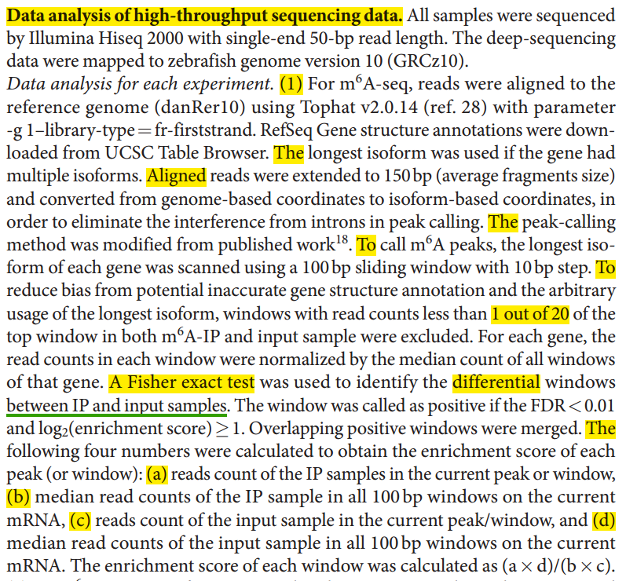

出自https://www.nature.com/articles/nature21355

根据文献method总结起来需要以下几步：

0. 前期：数据及reference下载
1. alignment
2. extend reads
3. select longest transcript and slide widows 4.calculate count and exclude low count reads(less than 1/20 top window)
4. calculate fisher P value and FDR adjust
5. merge windows with significant FDR.

# 应用场景

m6A-seq分析流程，从序列比对到call peak.

# 环境设置

> 本文档中所有代码都要在终端（Terminal）里运行。

建议使用Linux或MAC系统。Windows 10需要安装WSLhttps://docs.microsoft.com/en-us/windows/wsl/install-win10

安装以下软件：SRATools，hisat2，bedtools、samtools。方法如下：

- 下载安装SRATools，用于下载SRA数据和转成fastq格式，下载和安装方法看这篇：https://trace.ncbi.nlm.nih.gov/Traces/sra/sra.cgi?view=toolkit_doc&f=std。掌握了这个方法，就可以肆意下载已发表文章里的高通量测序的原始数据了。

```bash
# 先安装wget用于下载，可断点续传
conda install -c anaconda wget

# 下载SRATools，用于下载测序数据
wget https://ftp-trace.ncbi.nlm.nih.gov/sra/sdk/2.9.6-1/sratoolkit.2.9.6-1-mac64.tar.gz
# 解压缩，设置环境变量或者直接把prefetch和fastq-dump文件复制到当前文件夹就可以用了。

# 或者用conda安装
conda install -c daler sratoolkit
```

- 安装hisat2，用于把测序数据回帖到基因组：

```bash
conda install -c bioconda hisat2
```

- 安装bedtools、samtools，用于sam、bed文件处理

```bash
conda install -c bioconda samtools
conda install -c bioconda bedtools
```

# 输入文件

需要下载测序结果、参考基因组序列和注释。

- 测序数据，储存在SRA数据库中。从文章中找到线索，一般搜GSE或SRA就能从正文找到数据ID。示例文章的数据ID是GSE79213，进入GEO数据库，找到这套数据：https://www.ncbi.nlm.nih.gov/geo/query/acc.cgi?acc=GSE79213，能下载到peak.bed和FPKM文件。我们需要从头开始跑，要下载原始的fastq文件，因此，需要到SRA数据库中去下载。在“SRA”这三个字母右侧看到SRP071818，点击链接进入。我们以GSM2088162 input-0 和GSM2088167 m6A-IP-0为例来建立pipeline，分别对应SRR3228697和SRR3228702
- 参考基因组序列，下载自ensemblhttp://asia.ensembl.org/info/data/ftp/index.html，zebrafish version11（原文用的是10）。 序列：ftp://ftp.ensembl.org/pub/release-97/fasta/danio_rerio/dna/Danio_rerio.GRCz11.dna.primary_assembly.fa.gz， 注释：ftp://ftp.ensembl.org/pub/release-97/gff3/danio_rerio/Danio_rerio.GRCz11.97.chr.gff3.gz

在终端输入命令下载：

```bash
### 下载测序数据
# 用prefetch下载SRR
./prefetch SRR3228697
./prefetch SRR3228702

# 把SRR转成fastq格式
./fastq-dump SRR3228697
./fastq-dump SRR3228702

### 下载参考基因组
# 直接下载primary_assembly
wget ftp://ftp.ensembl.org/pub/release-97/fasta/danio_rerio/dna/Danio_rerio.GRCz11.dna.primary_assembly.fa.gz
# 或下载所有单个chromosome文件，再cat成一个fa文件
wget ftp://ftp.ensembl.org/pub/release-97/fasta/danio_rerio/dna/Danio_rerio.GRCz11.dna.chromosome.1.fa.gz
wget ftp://ftp.ensembl.org/pub/release-97/fasta/danio_rerio/dna/Danio_rerio.GRCz11.dna.chromosome.25.fa.gz
gunzip Danio_rerio.GRCz11.dna.chromosome.*.fa.gz
cat Danio_rerio.GRCz11.dna.chromosome.*.fa > Danio_rerio.GRCz11.dna.chromosome.fa

# 下载基因注释
wget ftp://ftp.ensembl.orpub/release-97/gff3/danio_rerio/Danio_rerio.GRCz11.97.gff3.gz
```